# Consequences of Bottle Bills: How Bottle Deposit Return Schemes Affect Retail Prices and Lead Consumers to Larger Package Sizes

Converted from PDF `Keller-BottleDepositReturnSchemes-2026-JM.pdf` · 22 pages · anchors: page `#pN`, block `#pN-bK`

Page 1

Consequences of Bottle Bills: How Bottle Deposit Return Schemes Affect Retail Prices and Lead Consumers to Larger Package Sizes

#### Kristopher O. Keller and Jonne Y. Guyt

Abstract Plastic waste has doubled in the past two decades, and less than 10% of plastic waste is recycled. “Bottle bills” are legislation to combat plastic waste by increasing recycling rates, by adding a per-bottle deposit that gets refunded to consumers who return empty containers. Industry experts are divided over the retail sales and price implications of such measures. To clarify the implications of such legislation, the current study uses a synthetic difference-in-differences approach to investigate how New York’s 2009 law, targeting pure bottled water in containers of less than 128 fl. oz., affected consumers and retailers in terms of whether prices of bottled beverages changed and whether the bottle bill affected sales of bottled beverages. The study also identifies three mechanisms that can drive such effects. The results reveal that retailers increased prices of items covered by the bottle bill by 4% while keeping prices of other items, outside the bottle bill’s scope, constant. Volume sales in the water category decreased by 6%. This study finds substantial differences in these effects across package sizes and provides suggestive evidence that consumers’ ideological aversion and retailers’ additional operational effort and holding costs are related to these sales and price changes.

Keywords bottle bill, deposit return system, responsible retailing, marketing conduct, plastic waste, synthetic difference-in-differences

Online supplement: https://doi.org/10.1177/00222429251347284

Submitted December 31, 2023

Even as plastic waste has doubled in the past two decades, less than 10% of plastic waste gets recycled globally (OECD 2022). Instead, plastic bottles often get sent to landfills, from which they leach and pollute rivers, or wind up as roadside litter, which is costly to clean. Furthermore, carbon emissions from plastic production are up to 40% lower when recycled materials are used, compared with virgin materials (Saleem et al. 2023). Bottle deposit or container deposit legislation (i.e., bottle bills) seeks to increase recycling rates by mandating that consumers pay a deposit for each container they purchase (e.g., 5¢ per bottle of water), which gets refunded if they return empty containers. Many regions have introduced bottle bills, such as countrywide laws in Germany, Israel, Canada, Australia, and South Korea, and others are in the process of doing so. In 2022, the European Commission issued a directive for all 27 member states to adopt deposits for plastic bottles by 2029 (see Web Appendix A for an overview of existing and impending bottle bills worldwide). Ten U.S. states, including

New York, Iowa, and California, also have bottle bills in place and continue to expand them (Quinn 2022, 2025), affecting more than 130 million people.

This embrace of bottle bills should come as no surprise, considering evidence that they generally work well in improving recycling rates (Campbell et al. 2016). States with bottle bills have average recycling rates of about 70%; those without them often exhibit rates below 30%. In turn, their beverage container litter is 69%–84% lower and their total litter is 30%–65% lower—a statistic that underscores the detrimental contributions of beverage containers to total litter (Bottle Bill Resource Guide 2023a). Despite this suggestive evidence related to

Kristopher Keller is Assistant Professor of Marketing, Kenan-Flagler Business School, University of North Carolina at Chapel Hill, USA (email: kristopher_keller@kenan-flagler.unc.edu). Jonne Guyt is Associate Professor of Marketing, Amsterdam Business School, University of Amsterdam, Netherlands (email: J.Y.Guyt@uva.nl).

Article

Journal of Marketing 2026, Vol. 90(3) 59-80 © The Author(s) 2025

Article reuse guidelines: sagepub.com/journals-permissions DOI: 10.1177/00222429251347284

journals.sagepub.com/home/jmx

Page 2

environmental outcomes, bottle bills face steep opposition (Gathright and Flynn 2025; Quinn 2022). For example, the International Bottled Water Association lobbies against bottle bills as they “will hurt consumers, jeopardize businesses, and impact … recycling efforts” (International Bottled Water Association 2009). Other beverage industry actors typically also oppose bottle bills, arguing such regulation might affect consumers, citing the added handling costs for empty, returned containers (Corkery 2019). For consumers, returning bottles to obtain deposits is inconvenient, and they face increased expenses in terms of both their effort to return bottles and their expenses if they choose not to return them. Such costs could drive consumers to buy less or shift to buying larger containers, for which the relative burden of the per-bottle deposit is less.

In light of such potential consequences of bottle bills, it is pertinent to shed light on their effects on retailers and consumers. In response, we establish three research questions we attempt to answer to advance extant literature. First, do the prices of both covered and noncovered bottled beverages change in response to bottle bills? Second, do bottle bills affect sales of both covered and noncovered bottled beverages? Third, what mechanisms might drive these effects?

In our effort to resolve these questions, we consider the introduction of a bottle bill that applied to bottled (or pure) water in containers of less than 128 fl. oz. (larger containers are not covered by this bottle bill) in New York state in 2009. We use two years of weekly sales data (from one year before to one year after the bill’s introduction) in the bottled water category (soda and other bottled beverages were already covered by a bottle bill for several decades). Our identification strategy rests on a synthetic difference-in-differences (SDID) framework, such that we compare sales of Universal Product Codes (UPCs) before and after the legislative change with the same UPCs sold by the same retailers in control states that were not subject to a bottle bill (yet).

With this approach, we determine that retailers increase the prices of package sizes covered by the bottle bill by 4% on average and by up to 13% for smaller package sizes (11 fl. oz.) but do not change the prices of packages outside the bottle bill’s scope (i.e., those ≥128 fl. oz.). At the same time, volume sales in the water category decreased by 6%, reflecting losses among the most popular package size of 16.9 fl. oz. (−15%), while larger package sizes (≥33.8 fl. oz.), including those not covered by the bottle bill (128 and 320 fl. oz.), gained sales of about 10%. Attesting to the generalizability of these insights, we provide several robustness checks and replicate the findings using a different bottle bill introduction, in Connecticut.

In addition, we find tentative support for two of the three mechanisms of the observed price and sales changes: ideological aversion and retailer costs. Consumers who dislike governmental interventions switch to larger package sizes, reducing (or avoiding altogether) the burden of the policy change. Next, we provide evidence that suggests retailers with higher operational effort and holding costs tend to increase the price differential to

noncovered bottles more than retailers with low additional effort and holding costs. We also empirically assess whether price sensitivities change after introduction of the bottle bill, giving retailers opportunities to adjust prices, but find limited evidence for this mechanism.

In supplementary analyses, we assess the profit implications of the observed price and sales changes and find that cost increases need to be substantial to justify the observed price increases from a profitability perspective. Finally, we provide a scenario analysis for changes in plastic waste. We document an increase in consumption of larger, noncovered package sizes, which may be less likely to be recycled and could paradoxically increase plastic waste. We find that shifts across package sizes appear dwarfed by the reduction of plastic waste through recycling.

In the remainder of the article, we first discuss how bottle bills work and how they differ from other policy interventions, such as soda taxes, followed by institutional details on our research context. Then, we take stock of the limited literature on bottle bills before we discuss how they may affect consumers and retailers. We then discuss our method, the results, and insights on the three proposed mechanisms, and end with a discussion.

#### Bottle Bills and Other Policy Interventions

Taxes have been the traditional tool that policy makers and economists apply to deal with environmental externalities such as litter. However, taxing littering or dumping is theoretically possible but hard to enforce (see, e.g., Porter 2002), leading to the advent of bottle bills. Bottle bills intend to reduce the societally undesirable behavior of incorrectly disposing of bottles, or worse, littering, and work by charging a refundable deposit on consumers’ purchases, which is refunded upon returning an empty container. Still, by using financial incentives (as opposed to, e.g., public awareness campaigns), bottle bills share some similarities with other policy tools such as excise taxes, temporary VAT (value-added tax) reductions, or import tariffs, which are all aimed at altering purchase or consumption levels of a set of products, rather than a product’s disposal.<sup>1</sup> In marketing, particularly soda taxes have received attention (e.g., Bollinger and Sexton 2023; Ching and Goetz 2024; Kim, Lee, and Gupta 2020; Seiler, Tuchman, and Yao 2021),<sup>2</sup> and studies have documented a sizable decrease in consumption, along with heterogeneous

1 Technically, a deposit return scheme can be framed as a tax and a subsidy that can achieve the same equilibrium as Pigovian taxes, in situations where individual litter measurement is intractable (Fullerton and Wolverton 2000). While this framing makes economic sense, people perceive taxes and deposit return schemes differently, as evidenced by a high support for the latter in states that have adopted a bottle bill (Porter 2002), versus a general dislike for taxes (Sussman and Olivola 2011). Throughout the remainder of the article, we do not refer to deposit return schemes or bottle bills as taxes. 2 For an excellent overview of the literature on soda taxes, see Ching and Goetz (2024).

60 Journal of Marketing 90(3)

Page 3

changes in marketing conduct and its effectiveness. However, bottle bills differ from soda taxes in their purpose, the complexity of the implementation, saliency in the store, and impact on consumers.

First, bottle bills have an environmental focus in that they are primarily designed to affect the postconsumption stage, encouraging recycling and reducing litter. Soda taxes, in contrast, are mainly designed to discourage harmful behavior (consumption of sodas), promote (consumer) welfare, and raise revenue (e.g., for a city). While taxes compel consumers to change their purchasing behavior, bottle bills do not do so; instead, they focus on nudges after consumption. Critically, with substantial consumer reactions such as those observed in the soda tax literature, retailers react and update their marketing conduct (e.g., Keller, Guyt, and Grewal 2024; Seiler, Tuchman, and Yao 2021). Considering bottle bills, which aim to alter postconsumption behavior, one might not expect to see additional marketing conduct adjustments, such as price changes.<sup>3</sup> In summary, while taxes typically aim to lower purchases by substantially increasing prices, bottle bills aim to increase recycling via a relatively small financial nudge without price increases.

Second, bottle deposit systems are operationally complex and involve multiple stakeholders in that they create circular systems in which consumers, retailers, and distributors work together. In contrast, soda taxes are much simpler because they are levied at a single place (mostly the distributor), facilitating easy integration into existing tax systems. Distributors and retailers must then decide how much of this tax to pass to consumers. For bottle bills, no such decision takes place. Distributors often retain (parts of) unredeemed deposits, while retailers receive a handling fee—the deposit itself does not affect any stakeholder financially in the same way, as it can always be reclaimed. Figure 1 illustrates the money flow in both bottle deposit and soda tax systems. The operational differences between soda taxes and bottle bills make it such that consumers and businesses may readily expect price changes in the case of an already sizable soda tax, providing ample reasoning for retailers to adjust their pricing portfolio. In contrast, with bottle bills, such expectations do not readily follow, making it unclear whether retailers will adjust pricing and how consumers would react to these price changes, should there be any.

Third, bottle deposits are typically added only at the checkout rather than included on the shelf price. This makes the deposit much less salient than if added to the shelf price. If so, consumers may not consider the deposit in their decisionmaking as much as they would if it were included in the shelf price. Indeed, in the context of taxes, prior work (e.g., Chetty,

Looney, and Kroft 2009; Ching and Goetz 2024) has shown that saliency plays a substantial role in consumer reactions to price adjustments: Even taxes of 6.5% have no negative effect on water sales if added at the checkout. Thus, one may not expect sales changes with a refundable deposit only added at the checkout.

Fourth, from a consumer perspective, while soda taxes are regressive measures, bottle bills are intended to be neutral and even have the potential to be progressive. Thus, the difference in financial incentives for these two policy measures has implications for which consumers are impacted disproportionally. Soda taxes tend to be regressive in that low-income consumers are particularly affected (Allcott, Lockwood, and Taubinsky 2019). Bottle bills, in contrast, create two opportunities for low-income or more price-sensitive consumers. First, they create a secondary market for collecting unreturned bottles that enables particularly low-income consumers to supplement some income (e.g., Ashenmiller 2011; Whiting 2024). Second, consumers may be concerned about being unable to return all bottles for their deposit. In response, they may consolidate their purchases among larger package sizes (e.g., four containers of 101.4 fl. oz. instead of 24 containers of 16.9 fl. oz.) where fewer deposits are needed and the relative water price is lower. Thus, bottle bills have the potential to be progressive (rather than regressive)—if retail prices are not adjusted.

In summary, juxtaposing bottle bills with soda taxes reveals that their effects on consumers and retailers may differ. Next, we provide institutional details on the bottle bill in our study, after which we discuss the existing literature on bottle bills and how they may affect prices and sales.

#### Institutional Details on New York’s Bottle Bill

In this article, we study the introduction of New York’s bottle bill on bottled water. The primary purposes of New York’s bottle bill were to promote recycling, reduce litter, and ease the burden on solid waste facilities (New York State 2014). An existing bottle bill law, enacted in 1982, covered beer, carbonated soft drinks, soda water, and other malt beverages; an amendment in 2009 expanded its coverage to bottled water.

The deposit is levied by “deposit initiators” (i.e., the first bottler, distributor, retailer, or agent acting on their behalf), which collect a 5¢ deposit per container from retailers. Consumers then pay the 5¢ deposit to retailers for each purchased container. The deposit is a separate item on the receipt, and the advertised shelf price typically does not include the deposit amount, which is added at the checkout. When they return empty containers, consumers receive refunds, and the retailers are reimbursed their previously paid 5¢ deposit, together with a 3.5¢ handling fee (independent of the bottle size) provided by the deposit initiator. Deposit initiators (e.g., distributors) must grant 80% of their unclaimed deposits to the New York State Department of Taxation and Finance. No distributors or retailers are exempt, and consumers can return empty bottles to any retail location (including those other than the location of purchase) or dedicated redemption

3 Further support for this notion can be found in Porter (2002, p. 182), which states that “on the basis of all the evidence from Oregon and Vermont and simulation studies, the expectation for Michigan under mandatory deposits was for little or no beverage price increases.” This difference is also reflected in the typical financial burden for consumers: In the United States, soda taxes are typically between 1¢/fl. oz and 2¢/fl. oz, while bottle deposits are refundable typically at 5¢ (but can be up to 10¢) per bottle. For a 16.9 fl. oz. bottle, a typical tax (1.5¢/fl. oz.) would amount to 25¢, while a refundable bottle deposit is only 5¢.

Keller and Guyt 61

Page 4

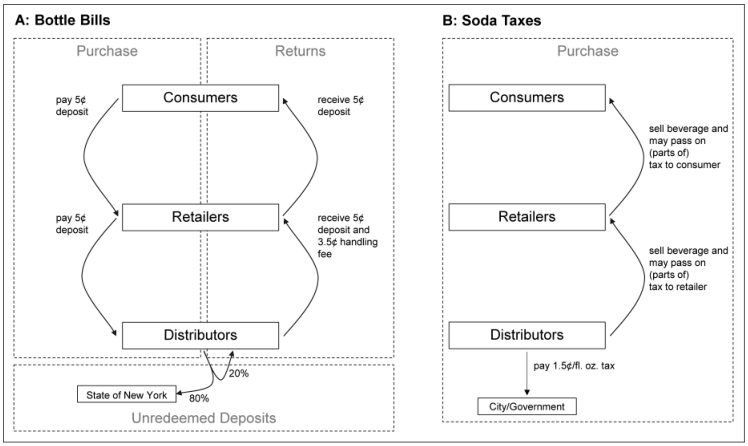

NOTE: figure/graphic rendered as an image from the PDF; its content is not machine-readable text. Caption (if any) follows as the next block.

centers.<sup>4</sup> Plastic bottles (as well as metal, aluminum, and steel containers) are included if their package size is less than a gallon (128 fl. oz.), as illustrated in Figure 2.

The bottle deposit is per package, not per volume, so consumers face heterogeneous outcomes at checkout, as we can illustrate with three package sizes. If consumers purchase a 24-pack of 16.9 fl. oz. bottled water (total of 405.6 fl. oz.) for $5.89, they pay $1.20 (i.e., 24 ×5¢) in bottle deposits (20% more). But for a four-pack of 101.4 fl. oz. bottles (also 405.6 fl. oz.), the deposit is only $.20 (i.e., 4×5¢). No deposit is due regardless of how many 128 fl. oz. bottles they buy. Thus, consumers have economic incentives to purchase fewer units of larger volumes.

#### Contribution and Existing Insights on Bottle Bills’ Effects

This study makes several contributions to the literature on responsible retailing, which generally focuses on societally relevant marketing initiatives and regulatory interventions on businesses and consumers’ reactions to policy interventions, and to the few studies related specifically to bottle bills. More

generally, our understanding of how policy interventions can promote a more sustainable retail environment (“responsible retailing”) is still in its infancy. Burgeoning literature on the effect of regulations on consumer and supply-side responses indicates that consumers buy less in response to a tax increase (Seiler, Tuchman, and Yao 2021), as well as that retailers adjust their marketing conduct to taxes (Keller, Guyt, and Grewal 2024) and nutritional warning labels (e.g., Alé-Chilet and Moshary 2022) in ways that might undermine or enhance the effect of well-designed policies (Cornelsen and Cuevas 2023). The literature is less clear, however, on whether (and if so, how much) consumers react to bottle deposits, which are only added at the checkout. Sussman and Olivola (2011) document that consumers dislike a tax more than a regular price increase, likely resulting in noticeable changes in shopping behavior. In contrast, Chetty, Looney, and Kroft (2009) document that consumers react less to taxes charged at the checkout than to similar taxes included in the shelf price. Supporting this notion, Ching and Goetz (2024) find that bottled water sales remained virtually unchanged when Washington state added an excise tax at checkout.

Industry experts are divided over the sales implications of bottle bills and the academic literature is sparse on the effects of bottle bills, enabling us to contribute in a variety of ways. An Information Resources Inc. (IRI) study documents a sales decline in Australia’s New South Wales region vis-à-vis a

Figure 1. Money Flow on Bottle Bills and Soda Taxes. Notes: Panel A shows the flow of money from consumers to retailers and then to distributors upon purchase (left-hand side), and the reverse order for returns (right-hand side). Upon a return, retailers additionally receive a 3.5¢ handling fee. For unredeemed deposits, 80% of the 5¢ deposit fee goes to the State of New York, whereas distributors keep 20%. Panel B shows the implementation of a soda tax, which a distributor needs to pay to the city or government directly. The distributor then decides on the pass-through of this cost to the retailer, which in turn decides on the pass-through to consumers. Distributors are typically bottlers that work on behalf of beverage manufacturers. Bottle bill values are for New York; soda tax values are based on those in Philadelphia, Pennsylvania. In bottle bills, bottles may at times also be returned to dedicated return centers rather than to retailers.

4 Stores larger than 5,000 sq. ft. are required to accept all types of returnable containers, while stores smaller than 5,000 sq. ft. typically only have to accept brands and sizes they sell.

62 Journal of Marketing 90(3)

Page 5

[figure not shown]

NOTE: figure/graphic rendered as an image from the PDF; its content is not machine-readable text. Caption (if any) follows as the next block.

control region following a bottle bill expansion (IRI 2018). Nonprofit organizations and environmental advocates, however, argue that concerns about sales changes due to bottle bills are unfounded (Berck and Goldman 2003; Bottle Bill Resource Guide 2023a; Massachusetts Department of Environmental Protection 2011). A widely cited recent report, analyzing multiple bottle bills using before–after comparisons and integrating other studies, concluded there is no “evidence that [bottle bills negatively] impact sales” (Collins et al. 2023, p. 4).

The academic literature is largely silent on bottle bills’ effect on sales, partly due to a lack of data, as suggested in Porter (1983, p. 187): “Neither levels nor changes of soft drinks sales in Michigan are known, much less the impact on sales of mandatory deposits.” Some early academic studies assess consumers’ evaluations, acceptance, and satisfaction with bottle bills (Crosby, Gill, and Taylor 1981; Crosby and Taylor 1982; Pilling, Crosby, and Ellen 1991; Wiener 1993). More recent studies contrast bottle bills to municipal recycling initiatives (Campbell et al. 2016) and show that bottle bills can substantially increase recycling rates (Viscusi et al. 2013) and effectively transfer income to lowerincome households (Ashenmiller 2011). In particular, we contribute to the literature on the economic implications of bottle bills. We are the first to study a representative bottle deposit on nonalcoholic beverages, whereas earlier studies looked at deposits for beer in Michigan in 1978,<sup>5</sup> where the bottle bill introduction coincided with a shift in the legal drinking age, potentially biasing any effects (Porter 1983; Sjolander and Kakela 1988). We also contribute by studying the effects on sales and prices charged to consumers (rather than just shipments to resellers such as breweries or restaurants), using much richer and more fine-grained data (weekly, store-level product level data rather than annual casebased shipments) with a clear identification strategy based on comparable control units (vs. before–after comparisons with concurrent events), and we study important effects on noncovered containers (rather than covered containers only).

These detailed data, reflecting both covered and noncovered products, enable us to also assess three relevant mechanisms, providing first insights into why these effects occur and why they may not be homogeneous (see the next section for additional details). By relating consumers’ ideological aversion to governmental intervention, we also contribute to the literature on public policy compliance morale and the literature on consumer ideology. The literature on public policy compliance has shown that, for example, political alignment with the sitting president influences tax evasion behavior (Cullen, Turner, and Washington 2021), Democrats tend to be more responsive to energy conservation nudges (Costa and Kahn 2013) and adhere more to social distancing guidelines (Allcott et al. 2020), and voting behavior for a particular policy is linked to the policy’s effectiveness (Ching and Goetz 2024). We add to this literature by showing that ideological aversion to policy interventions is related to shifting purchases toward products not covered by this intervention, even after accounting for differences in stockpiling costs. We also add to the retailer-pricing literature by studying whether a change in aggregate price sensitivities may play a role in how retailers adjust prices. While previous literature has shown that seasonal and cyclical demand, leading to differential price sensitivities, results in retailer price adjustments (e.g., Butters, Sacks, and Seo 2025; Nevo and Hatzitaskos 2005), it is unclear if external shocks such as a bottle bill push price-sensitive households to different products or out of the market.

Finally, we contribute to a nascent literature stream documenting the degree and speed of adjustments in retailer prices due to cost shocks (Alvarez et al. 2025; Butters, Sacks, and Seo 2022). In our setting, a bottle bill with a uniform deposit levied for a subset of bottles leads retailers to adjust prices of covered UPCs while prices of noncovered UPCs remain largely stable. Moreover, we find suggestive evidence that the degree to which prices are adjusted is aligned with the efforts and holding costs retailers incur rather than the deposit’s flat rate itself.

#### Effects of Bottle Bills on Sales and Prices and the Mechanisms of These Effects

Consumers may receive a refund of their deposit, but returning the bottle is likely perceived as a hassle (Ashenmiller 2011).

Figure 2. Bottle Sizes and Their Inclusion in New York’s Bottle Bill.

5 The Michigan bottle bill discussed in Porter (1983) and Sjolander and Kakela (1988) was expected to aid the comeback of a refillable bottle (instead of a nonrecyclable container, which was becoming more popular). This comeback did not happen. Currently, containers are virtually exclusively plastic (or cans in nonwater categories) and recyclable, with bottle bills aiming to improve recycling rather than the use of refillable containers (Porter 2002).

Keller and Guyt 63

Page 6

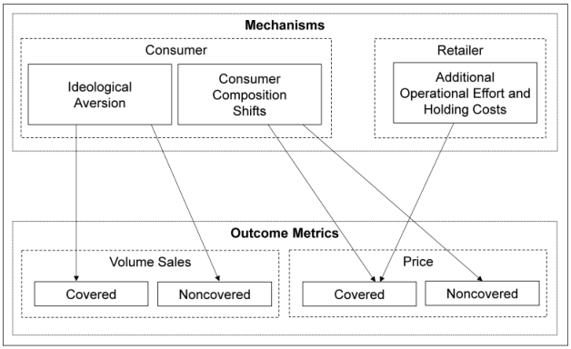

NOTE: figure/graphic rendered as an image from the PDF; its content is not machine-readable text. Caption (if any) follows as the next block.

Moreover, perfect return rates are unrealistic; they hover around 70% in markets subject to bottle bills (Bottle Bill Resource Guide 2023a). Consumers, thus, may anticipate that they will not receive a full refund of the deposits they pay. If consumers perceive this difference as a type of levy or tax, they could respond by buying less (i.e., lower sales) or shifting to larger package sizes, where the burden is relatively lower.<sup>6</sup>

However, there are reasons to believe that volume sales might not change at all with a refundable deposit. Typically, deposits are only added to the price paid at the checkout. Such nonsalient price changes may have limited effects on sales (Chetty, Looney, and Kroft 2009; Ching and Goetz 2024).

Retailers may adjust prices to recover the potentially increased costs of implementing the bottle deposit system. Indeed, some retailers argue (Gathright and Flynn 2025; Moses 2005) that they receive partial, and allegedly insufficient, compensation for this effort (e.g., Corkery 2019), which increases their costs in three main ways. First, they must purchase and maintain bottle deposit facilities, for which they have to pay staff to operate them and keep the surrounding areas clean because bottle returns often result in spills. Second, they face the opportunity cost of scarce floor space taken up by bottle return systems (e.g., Gibbons 2021;

Livengood 2022). Third, retailers typically pay the deposit up front, increasing inventory holding costs before receiving the deposit from consumers.

Moreover, because bottle bills typically levy a deposit per bottle, independent of its size or handling costs, retailers may revise their pricing depending on the bottle size rather than a blanket price increase across sizes. Thus, the way consumers and retailers respond in terms of sales changes and price adjustments is unlikely to be uniform across products and retailers. Next, we discuss three important mechanisms of sales and price adjustments: ideological aversion that leads some consumers to avoid covered package sizes, shifts in consumer composition depending on their price sensitivity, and additional operational burden for retailers. In Figure 3, we combine these mechanisms of why consumers and retailers may adjust their conduct in response to a bottle bill and why it may differ for covered and noncovered products. We discuss these mechanisms next.

#### Ideological Aversion

While the regulation aims to induce societal benefits, consumers may dislike governmental regulations. More importantly, some consumers are more aversive of governmental interventions than others. Indeed, consumer ideology has been shown to drive consumers’ responses to policies (Allcott et al. 2020; Costa and Kahn 2013). In the United States, “conservatives consistently oppose environmental regulation” (Costa and Kahn 2013, p. 685) and a 2009 Pew survey (Pew Research Center 2009)<sup>7</sup> reported Republicans to have a 23 percentage point

Figure 3. Mechanisms of Sales and Price Changes After a Bottle Bill Introduction.

6 Should consumers perceive the flat deposit as a tax that is uniformly applied to all covered package sizes, larger (more expensive) package sizes also become more appealing due to the “third law of demand,” which states that an equal absolute increase in the price of two substitutes leads to a decrease in the relative price of the more expensive good. This is known as the Alchian–Allen effect (Alchian and Allen 1972, pp. 74–75) and is typically used to understand the effect of import tariffs on which products remain imported and exported. We note that the deposit fee itself is relatively low. Yet, any such effects may be amplified if retailers engage in additional price increases, especially if these increases are skewed toward smaller package sizes.

7 For more recent, substantively similar findings where there is an ideological gap in terms of environmental policies, see Jones (2023).

64 Journal of Marketing 90(3)

Page 7

lower agreement with the statement that people should be willing to pay higher prices to protect the environment, despite having similar baseline recycling behavior. Put differently, Republicans may tend to be more ideologically averse to bottle bills than Democrats. When faced with a bottle bill, we argue that ideological aversion to government intervention is correlated with consumers avoiding the bottle bill by reducing purchases of covered package sizes (or shifting to larger package sizes, where the burden is lower) and turning to noncovered package sizes instead.

#### Price Adjustments Because of Consumer Shifts

Next to variation in shopping habits driven by consumers’ ideology, consumers may adjust their purchasing based on their price sensitivity. Specifically, consumers’ price sensitivity might lead them to switch to larger bottles to minimize the deposit paid per fluid ounce or choose package sizes not covered by the bill to avoid the deposit altogether. Such shifts would alter the consumer composition within each package size. That is, more price-sensitive consumers are more likely to opt for larger packages, leaving the set of consumers purchasing smaller package sizes to be less price sensitive. Shifts of price-sensitive consumers may prompt retailers to implement price adjustments. Price adjustments that are consistent with changes in demand elasticities have been found by Nevo and Hatzitaskos (2005) and Butters, Sacks, and Seo (2025), in which seasonal variation in demand leads retailers to adjust their pricing. In our case, retailers would need to be aware of or expect a different price sensitivity after the bottle bill is implemented.

#### Additional Operational Effort and Holding Costs

Implementing a bottle bill is costly for retailers, as they must ensure correct labeling on the bottles and install return machines that take up precious store space (Corkery 2019). In addition, while retailers receive the deposit fee from consumers, they must first pay the deposit fee to distributors. Thus, while bottles are in retailers’ inventory (i.e., before they are sold to consumers), retailers bear the deposit fee. This results in increased inventory holding costs. Retail managers may be tempted to increase prices to offset the expected negative impact of the bottle bill.<sup>8</sup> For example, when a soda tax was implemented in Boulder, Colorado, some retail managers responded by increasing prices by more than the value of the tax (Cawley et al. 2021). Keller, Guyt, and Grewal (2024) document the same phenomenon in Oakland and San Francisco, California. Such price increases might offset the cost increase, but they are unlikely to affect all package sizes equally,

because from a cost perspective, it is easier to store and handle larger-volume bottles than multiple smaller bottles that add up to the same volume. Keeping total volume constant, two smaller bottles represent more handling and storage costs than a single larger bottle; they also contain more plastic (see Web Appendix C). Thus, retailers might want to incentivize consumers to buy larger packages by differentially increasing prices according to package sizes. For package sizes not included in the bottle bill (e.g., 128 fl. oz. or larger in New York), handling costs do not increase, and we do not expect retail price increases. As importantly, these increases are unlikely to be uniform across retailers. The larger a retailer’s additional efforts and holding costs through the bottle deposit (e.g., because of a larger bottled water assortment), the more likely one may expect to observe increased prices for covered package sizes.

Summarizing, we advance three mechanisms of sales and price effects of bottle bill introductions. We argue that ideological aversion plays an important role in the size of consumers’ reactions and that a change in aggregate price sensitivities provides opportunities for retailers to adjust prices. Independent of consumer composition changes, retailers, too, differ in whether they increase prices for covered bottles, mainly due to the additional operational effort and holding costs they experience.

#### Data

We gather water sales data from NielsenIQ Retail Measurement Services, provided by the Kilts Center for Marketing. These data include detailed information at the UPC–store–week level for almost the entire United States, including the UPC’s package size and type of water (mineral, pure, or specialty), which we use to determine whether the UPC is affected by a bottle bill (i.e., pure water in package sizes smaller than 128 fl. oz.). Store information includes the market (defined by the three-digit zip code) and state. We include 52 weeks before and 52 weeks after the bottle bill introduction in October 2009.

In addition to volume (in fluid ounces), we obtain data about UPC unit prices, which we use to construct each UPC’s price per fluid ounce. As is common for retail scanner data, we rely on sales data to infer UPC stocking decisions that result from a lack of product availability. Similar to Hwang, Bronnenberg, and Thomadsen (2010), we consider all products part of the assortment unless they prompt no sales for more than four weeks.

The bottled water category is characterized by nine standard package sizes (8, 11, 16.9, 20, 23.7, 33.8, 101.4, 128, and 320 fl. oz.), each of which accounts for at least 1% of sales in the category; they jointly account for more than 98% of all sales (i.e., any other package types have very small sales volumes; we exclude one UPC due to unrealistic price data). For the analyses, we retain all stores that have more than $100 in weekly sales and that are not taken over by another retailer, and all UPC–store pairs consistently offered, in both a treated market and its control markets (DellaVigna and

8 Retailers also might adjust their assortment or change their usage of feature advertising in store flyers and in-store displays. We find some minor adjustments to the assortment that are economically negligible, which we discuss in Web Appendix B. We find no evidence for changes in the use of feature advertising and in-store displays.

Keller and Guyt 65

Page 8

Gentzkow 2019). UPCs that are sold in both treated and control markets represent more than 87% of total volume sales.

Our sample frame covers 110 unique UPCs in the bottled water category, sold through 1,415 stores in the state of New York, resulting in 13,752 UPC–store pairs. As control units, we use the same UPC, sold by the same retailer in stores that are located in the United States. We exclude UPC– store pairs with one control unit only and stores from states that feature a bottle bill and markets (defined by the three-digit zip code) that share a border with the state of New York. Using control markets that are not neighbors reduces the likelihood of treatment spillovers (i.e., violations of the stable unit treatment value assumption [SUTVA]<sup>9</sup>), which may apply to both supply (coordination of pricing across markets) and demand (cross-border shopping/evasion of the bottle bill) sides. Figure W4 in Web Appendix D provides a graphical description of the treated state (New York) and a snapshot of the area from which we source control units. Table 1 presents, by package size, information about the number of treated and control UPC–store pairs available, and the multipack types (and their market share within the package size).

#### Model-Free Evidence

Before presenting our model, we provide some descriptive statistics and model-free evidence on changes in sales and prices across treated and control units. Table 2 presents, by package size, average volume sales and prices for the 52 weeks leading up to the bottle bill introduction in October 2009, and volume sales and prices in the immediate 52 weeks after. We also show relative changes and the absolute change in price per bottle. For treated UPC–store pairs (Table 2, Panel A) the averages suggest that volume sales changed noticeably

following the bottle bill introduction. For example, sales of the most often sold package size (16.9 fl. oz.) fell by almost 7%, while larger package sizes tended to exhibit substantially higher sales. All covered package sizes (except 11 fl. oz. and a small decrease for 101.4 fl. oz.) feature actual price increases of up to 8% (23.7 fl. oz.); noncovered package sizes are subject to much smaller changes or even price decreases. At the unit price level, price changes range from a 14¢ reduction (320 fl. oz.) to a 6¢ increase (33.8 fl. oz.). Based on price changes alone, we might expect smaller package sizes to lose sales while sales of larger packages increase. The changes among control UPC–store pairs (Table 2, Panel B) provide additional insights into the observed changes in Panel A. For example, sales of several package sizes (11, 23.7, and 33.8 fl. oz.) changed in control markets, too, highlighting the importance of accounting for these. In terms of price changes, the observed small increase for 128 fl. oz. bottles was more pronounced among control markets, suggesting an actual decrease. In this light, the usual caveats for before– after comparisons apply, and we address these next.

#### Method

We rely on a SDID approach to identify the effects of the bottle bill, in line with other studies identifying the effects of policy interventions using a pre–post comparison of treated and control markets (e.g., Guyt, van Lin, and Keller 2025).

The SDID estimator combines the strengths of two related methods: the synthetic control method (SC), as introduced by Abadie and Gardeazabal (2003), and difference-in-differences (DID), as used by Bertrand, Duflo, and Mullainathan (2004) for example. Similar to both SC and the standard DID approach, the SDID approach uses nontreated cases (i.e., pool of potential controls) to create a control unit for each treated unit—in our case, water UPCs sold in stores in the state of New York. To create the synthetic control unit, both SC and SDID use a weighted average of products from the pool of potential controls (in contrast to standard DID, which uses an unweighted

Table 1. Information on the Number of Treated and Control Cases by Package Size.

[output not shown]

NOTE: table converted from PDF layout to HTML text; cell boundaries are reconstructed. See PDF if exact alignment matters.

aNumbers in parentheses show each multipack type’s volume-based market share within its package size.

9 The SUTVA assumption also entails that each state would receive the same bottle bill treatment; that is, there would be a consistent treatment and no other interfering treatments or variations.

66 Journal of Marketing 90(3)

Page 9

average). The weights are selected such that they create a synthetic control that closely matches the pretreatment pattern of the outcome variable of the treated units, thereby making parallel trends more probable in the pretreatment period. The synthetic control unit’s posttreatment evolution provides a counterfactual prediction for the treated products, and the discrepancy between control and treated products can be interpreted as the result of the intervention (i.e., bottle bill introduction). While SC and SDID both include unit weights, SDID also employs time weights to help balance pretreatment with posttreatment periods and thus may make the parallel trends assumption more realistic. Similar to standard DID and

unlike SC, SDID is invariant to any baseline-level differences in dependent variables and enables valid large-panel (i.e., “large-N, large-T” settings) inferences.

To understand the effect of the bottle bill, we present the model that captures its effects on pricing, after which we turn to the model that captures its effects on volume sales. We estimate the model separately for each of the 110 UPCs.

#### Pricing

To capture the bottle bill’s effect on pricing, we estimate the following equation:

, (1)

where pust represents the absolute price (in cents per fluid ounce) of UPC u in store s in week t; ˆτ<sup>p</sup>

u <sup>captures the effect of the imple</sup>mentation of the bottle bill on the price of UPCs; α<sup>p</sup>

0u <sup>is an inter</sup>cept; α<sup>p</sup>

us <sup>and</sup> <sup>γ</sup><sup>p</sup>

ut <sup>are</sup> <sup>UPC</sup><sup>–</sup><sup>store</sup> <sup>and</sup> <sup>UPC</sup><sup>–</sup><sup>week</sup> <sup>fi</sup><sup>xed</sup> <sup>effects,</sup> respectively; Nu is the set of eligible UPC–store pairs in both the treated and control states for a given UPC for which we observe a balanced panel; ℓu,−52 denotes the start of the analysis window for UPC u, whereas ℓu,52 is the end; bottlebill_postust is

an indicator that equals 1 in the period after the bottle bill was implemented (for stores in New York); and ˆω<sup>p</sup>

us <sup>and</sup> <sup>ˆ</sup><sup>λ</sup><sup>p</sup>

ut <sup>are</sup> unit weights for the control UPC–store pairs and time weights, respectively, where the unit weights are chosen such that the pretreatment period of the controls has a parallel trend to the UPC–store pairs in the treated state and the time weights are chosen such that the pretreatment and posttreatment periods for the controls are similar (up to a constant). We obtain

Table 2. Changes in Sales and Prices Before and After Bottle Bill by Package Size.

[output not shown]

NOTE: table converted from PDF layout to HTML text; cell boundaries are reconstructed. See PDF if exact alignment matters.

Notes: Volume sales and price are averages per week by UPC–store pair. Unit price refers to the price per bottle.

Keller and Guyt 67

Page 10

standard errors using the jackknife method.<sup>10</sup> As in Arkhangelsky et al. (2021), the remaining idiosyncratic error is assumed to be Gaussian. We aggregate to the package size-specific treatment effect (ˆτ) and standard error, by weighting the UPCs by the respective number of treated UPC–store pairs (Arkhangelsky et al. 2021, p. 4114).

#### Volume Sales

The total effect of the bottle bill on volume sales is captured in a similar fashion to the price effect:

, (2)

where Sust represents the volume sales in fluid ounces for UPC u in store s and in week t. The bottle bill’s implementation effect is captured by ˆτ<sup>s</sup>

u<sup>.</sup> <sup>All</sup> <sup>other</sup> <sup>variables</sup> <sup>and</sup> <sup>parameters</sup> <sup>are</sup> <sup>as</sup> defined previously.

#### Results

We present the model-based results in three parts: (1) the causal effect of a bottle bill introduction on retail prices, (2) how a bottle bill introduction affects volume sales, and (3) estimates of several robustness checks based on the level of pooling of estimates, postintroduction evaluation periods, and choice of SDID method. We then turn to scenario-based insights on the profitability of such price changes and the total effect on plastic waste.

#### Effect of Bottle Bills on Retail Prices

We estimate Equation 1 and present the parameter estimates, aggregated to the package size level, in Figure 4. Detailed estimates are available in Table W8 of Web Appendix E.

The bottle bill increases retail prices (excluding the deposit) for all covered package sizes (<128 fl. oz.). That is, over and above the (refundable) deposit, consumers face higher prices, and the change is particularly pronounced for smaller package sizes. For the smallest package sizes, 8 and 11 fl. oz., prices increased by more than .40¢/fl. oz., representing increases of 11.9% and 13.0%, respectively. The other covered package sizes increased by .7% to 5.5%, with prices of 16.9 fl. oz., the best-selling package size, increasing by .14¢/fl. oz. (+5.5%). On average, the prices of covered package sizes increased by 4%. In contrast, prices for the package sizes not covered by the bottle bill, 128 and 320 fl. oz., changed only marginally, by about .008¢/fl. oz. (.8%) and .007¢/fl. oz. (.7%), respectively, for a weighted average of .8%. The unit price changes for each bottle size (calculated as the product of the estimated change, ˆτ<sup>p</sup>

u<sup>,</sup> and the package size) are smaller than the deposit for the most

popular size of 16.9 fl. oz. (2.4¢ price increase vs. 5¢ deposit), as well as all other covered sizes (3.3¢ for 8 fl. oz, 4.4¢ for 11 fl. oz, 4.9¢ for 20 fl. oz., 3.3¢ for 23.7 fl. oz., 2.2¢ for 33.8 fl. oz., and 1¢ for 101.4 fl. oz.).<sup>11</sup>

#### Effect of Bottle Bills on Sales

To quantify how the bottle bill changes sales, we estimate Equation 2 and present the associated parameter estimates in Figure 5 (see also Table W8 of Web Appendix E).

The sales effect of a bottle bill is substantially negative for the most popular package size, 16.9 fl. oz. Sales are lower by 1,978.82 fl. oz. per week (and UPC–store pair), representing a 14.88% reduction (i.e., −1,978.82 fl. oz. divided by 13,302.55 fl. oz.; see Table 2, Panel A). The sales levels for the other smaller packages (8 and 11 fl. oz.) do not change despite the noticeable price increases.

These sales losses are somewhat countered by sales changes of the 20 and 33.8 fl. oz. package sizes, showing sales increases of 46.15 fl. oz. (a 6.8% increase) and 35.94 fl. oz. (6.8% increase), respectively, and by the substantial increases in sales of the larger package sizes (101.4 fl. oz. and larger, ranging from a relative increase of 5.6% to 17.0%). Accounting for the relative importance of each package size (see “UPC–Store Pairs” in Table 1 and volume sales before the bottle bill implementation in Table 2, Panel A), the total sales loss across package sizes is 6.0% (see Web Appendix F for details).

#### Identification and Robustness Checks

Despite careful selection of control units (i.e., stores from nonneighboring markets reduce the likelihood of treatment spillovers) that do not violate SUTVA, other threats to identification require attention. We also note issues related to the viability of the chosen control markets, the parallel trends assumption, and the time window surrounding the bottle bill implementation.

10 Computing the standard errors via the bootstrap procedure results in virtually identical results in our setting.

11 Our price measure excludes the bottle deposit, which is charged at checkout on top of any retail price changes.

68 Journal of Marketing 90(3)

Page 11

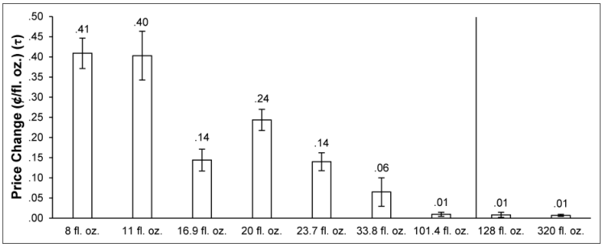

NOTE: figure/graphic rendered as an image from the PDF; its content is not machine-readable text. Caption (if any) follows as the next block.

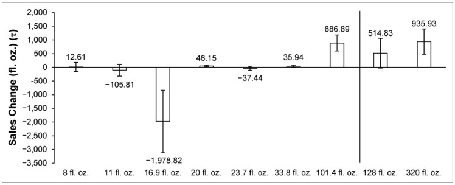

NOTE: figure/graphic rendered as an image from the PDF; its content is not machine-readable text. Caption (if any) follows as the next block.

Parallel trends. A key identifying assumption for our approach is that in the absence of the treatment, the sales and prices of UPCs in markets in New York would have evolved in parallel with those of the selected control markets. To assess the validity of our approach, we inspect the pretreatment trend similarity of the treated time series with that of the synthetic control (as derived through the SDID approach) and the average control (as would be used in a traditional DID). Across all UPCs for which we estimate our model, we find an average correlation of .70 for sales (.84 for prices) for treated and synthetic control and .64 for sales (.75 for prices) for treated and the average control unit. That is, volume sales and prices of the synthetic controls show higher correlations with the treated group in the pretreatment period than the raw (unweighted) controls

do. In Web Appendix D, we provide a more in-depth analysis, including pretreatment correlations (Table W7 and Figure W1) by UPC and a graphical inspection of the parallel trends (Figures W2 and W3) at the package size level.<sup>12</sup>

Still, rather than selecting all controls (as in DID) or weighting the controls (SDID), we also estimate our model with a subset of controls that may be more eligible. Specifically, we follow Bollinger and Sexton (2023, p. 292) and select up to

Figure 5. Effect of Bottle Bills on Volume Sales by Package Size. Notes: Bars show ˆτ<sup>s</sup>

u <sup>along with 95% con</sup><sup>fi</sup><sup>dence intervals. The solid vertical line represents the cutoff for covered package sizes in New York. Parameter estimates</sup> and standard errors at the package size level are computed as weighted average (with the number of treated UPC–store pairs serving as weights) across UPCs.

Figure 4. Effect of Bottle Bills on Retail Prices by Package Size. Notes: Bars indicate ˆτ<sup>p</sup>

u <sup>along</sup> <sup>with</sup> <sup>95%</sup> <sup>con</sup><sup>fi</sup><sup>dence</sup> <sup>intervals.</sup> <sup>The</sup> <sup>solid</sup> <sup>vertical</sup> <sup>line</sup> <sup>represents</sup> <sup>the</sup> <sup>cutoff</sup> <sup>for</sup> <sup>covered</sup> <sup>package</sup> <sup>sizes</sup> <sup>in</sup> <sup>New</sup> <sup>York.</sup> <sup>Parameter</sup> estimates and standard errors at the package size level are computed as weighted averages (with the number of treated UPC–store pairs serving as weights) across UPCs.

12 Because it is infeasible to graphically present parallel trends for 220 series (110 UPCs and two outcome metrics), we present the average trends at the package size level. However, we note that the key parallel trends assumption in the pretreatment period lies at the UPC level, which is why we present pretreatment correlations at the UPC level.

Keller and Guyt 69

Page 12

ten control units that exhibit the highest (average) pretreatment correlations across volume sales and prices. This achieves two goals: First, it selects a subset of control units that mechanically has a higher correlation between treated and control units. Second, by considering a high pretreatment correlation for both outcome metrics, we select control units that are likely to face similar (observed and unobserved) market conditions as both prices and sales evolve similarly as they are equilibrium outcomes.

In addition, we conduct in-time placebo tests, setting the placebo treatment in the middle of the pretreatment period (Week 27). This falsification test enables us to assess whether our treatment effects are due to the bottle bill or whether they may be driven by preexisting trends. For the vast majority of UPCs, we find no evidence of trend deviations, suggesting that the effects in our main analysis are indeed due to the bottle bill. We find statistically significant deviations for only a few effects (18 out of the 220 estimates). As importantly, our results are robust to dropping UPCs for which we find significant trend deviations. Web Appendix G provides additional information and detailed parameter estimates.

Level of analysis. To facilitate richer insights at the package size level, we estimate our main model for each of the 110 UPCs and then calculate an aggregate effect.<sup>13,14</sup> This estimation approach comes with two caveats. First, we lose power by estimating our models at a more disaggregate level. Second, our pool of potential controls for the SDID model is restricted to each UPC (e.g., for a given UPC, potential controls are restricted to the same UPC sold in control stores). In two robustness checks, we reestimate our main model across a larger set of treated units: at the package size–multipack level (e.g., 24-pack of 16.9 fl. oz.) and at the package size level (e.g., 16.9 fl. oz.), resulting in 27 and 9 estimations, respectively.

Difference-in-differences. A key identification assumption in our model is that of parallel trends. Our previous discussion on parallel trends highlights the increases in pretreatment correlations in the outcome variable between treated and control units when going from an unweighted control group to a weighted version (as in SDID). Nevertheless, for various UPCs, the unweighted control group may already satisfactorily address the parallel trend requirement. If so, then a traditional DID model is unbiased and more efficient (see, for an excellent discussion, Li and Van den Bulte [2023]). In a robustness check using the traditional DID model (with store-level clustered standard errors), we further assess the stability of our results.

Time window and store implementation. The bottle bill’s effects on sales and pricing may manifest quickly or after a delay.<sup>15</sup> In our main model, we consider a period of one year (52 weeks) before and after introduction of the bottle bill to estimate the effect. We omit the first four weeks after the bottle bill was implemented to account for the disruption created by this implementation in stores, where retailers needed to set up bottle return machines and communicate about the imposed deposits to customers (similar to Keller, Guyt, and Grewal 2024). Also, New York allowed for a grace period until early November (i.e., less than four weeks), until which stores had to charge the deposit.

#### Profit Implications of Price and Sales Changes

We document, on average, price increases and sales decreases for retailers, which counteract each other in terms of profit implications. Unfortunately, we cannot assess the net effect on retailers’ profits with the available data because a complete picture of the profit implications would need to include changes in handling costs, return rates, opportunity costs for

13 As we model the absolute price per fluid ounce, as well as absolute sales, our models do not suffer from any form of aggregation bias that would be present in log-log models (see, e.g., Christen et al. 1997). 14 The UPC-level analysis also enables us to provide first insights into potential variation across products. To this end, we separately assess the bottle bill effects for two classes of brands: store and national brands. Store brands hold a 13% market share in our setting and are available at most retailers and typically cheaper than national brands. We report the aggregated effects based on each brand type next to the aggregated effects across all UPCs in Web Appendix H. We find price reactions for store brands to be considerably more muted and economically small. This relates to literature on retail price pass-through: McShane et al. (2016) show that wholesale price changes for store brands are less likely to be passed on to consumers than those for national brands. Similarly, Bollinger and Sexton (2023) find that soda taxes are not passed on for store brands, possibly due to higher margins that can absorb cost shocks better. Interestingly, the sales for 16.9 and 8 fl. oz. increase, opposite to the effect for national brands. Also, sales of 101.4 fl. oz. increase more than those of national brands. It seems that store brands are an additional route through which consumers save without trading up to very large package sizes. Further research could establish why some consumers avoid the deposit by switching to noncovered sizes, while others economize by choosing store brands.

15 Alvarez et al. (2025) study cost shock pass-through to consumers in retail prices and find that shocks at the aggregate (category) level, such as those that come with a bottle bill, are completely passed through to consumers within a five-month window, suggesting that our one-year window should sufficiently capture the long-run effects.

70 Journal of Marketing 90(3)

Page 13

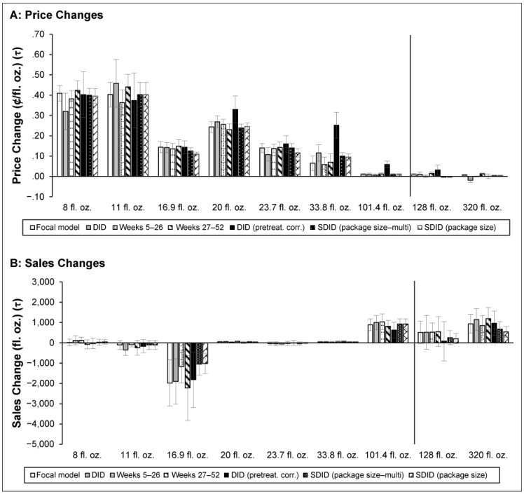

NOTE: figure/graphic rendered as an image from the PDF; its content is not machine-readable text. Caption (if any) follows as the next block.

the space, increased cleaning and staffing costs, and so forth. We are unaware of such detailed data but hope continued research might address these important questions. To gain some initial insights, we conduct a scenario analysis using our parameter estimates, observed recycling rates, and reasonable assumptions about gross margins. We calculate the level of additional costs at which retailers are indifferent to adopting a bottle bill from a profit perspective. We provide additional details of this analysis in Web Appendix J. Briefly, based on the observed price increases, we find that the additional costs retailers cite in opposition to bottle bills must be substantial— up to 6¢ per bottle if margins are low and equal to the reimbursement fee around margins of 30%—for retailers to be worse off with a bottle bill. This amount equals 2.5%–6% of

the average price of covered bottles prior to the implementation of the bottle bill.

#### Scenario Analysis for Plastic Waste

To determine if the documented increase in sales of larger package sizes paradoxically increases plastic waste, we combine our parameter estimates (Figure 5), the plastic amount per bottle (Web Appendix C), and New York’s recycling rate to calculate the amount of plastic sold and the total amount of unrecycled plastic across different scenarios. Specifically, for each package size, we determine the amount of plastic sold (unit sales × package weight), which we aggregate across

package sizes. We identify these values for both the situation without the bottle bill and that with the bottle bill, including the real-world observed price adjustments (τ<sup>S</sup>

u<sup>).</sup><sup>16</sup> <sup>We</sup> <sup>calculate</sup> the plastic waste for each scenario based on their typical recycling rates: 30% without and 70% with a bottle bill for covered package sizes (using 30% for noncovered package sizes).

These estimates suggest that the reduction in plastic waste among covered packages without higher recycling rates would be around 5.7%. However, as recycling rates are higher, introducing a bottle bill decreases plastic waste by 44% (from 33,070 to 18,458 kg/week). Therefore, any shifts across package sizes appear dwarfed by the reduction of plastic waste through recycling.

#### Spillover Effects on Other Product Categories

Thus far, our efforts have focused on the affected category itself, bottled water. While spillover effects on other product categories are unlikely (see, e.g., Seiler, Tuchman, and Yao 2021), it is an empirical question. In our setting, consumers may switch to on-the-go soda or energy drinks where returns are particularly inconvenient. The soda category is the second largest beverage category after bottled water, though only about half the size in terms of volume sales (soda sales are about 48% lower than water sales in New York); the energy drink category was only about 1.1% the size of the water category but was growing at the time. Both categories are already covered by a bill. If consumers switch to either category, we underestimate the effect on retailers’ sales and plastic waste, which would likely be higher. To gain some preliminary insights into this issue, we separately assess the effects of the bottle bill on to-go soda and energy drink products (all packages ≤33.8 fl. oz.). We calculate the aggregate sales at the category level (i.e., soda or energy drinks) in each treated and control state and estimate a SDID model on these 4,160 observations (40 states × 104 weeks). We find no evidence of economically or statistically significant spillover effects on either the soda (p = .20) or the energy drink (p = .11) category. This leads us to conclude that the risk of underestimating effect sizes due to spillovers on other categories is minimal in our setting.

#### Mechanisms of Retail Price and Sales Changes

Thus far, we have established that bottle bills are associated with higher prices for covered package sizes and a shift in sales from smaller to larger package sizes, but we have not yet developed an understanding of why these patterns are present. Next, we provide additional analyses that provide support for three mechanisms, that is, how ideological aversion, price sensitivity, and retailer costs relate to the observed pricing and sales patterns.

#### Ideological Aversion

Approach. To understand whether ideological aversion is related to the sales changes for covered and noncovered package sizes, we estimate market-specific effects and correlate these with a market’s ideological aversion, represented by its political voting pattern. Specifically, we reestimate Equation 2 separately for each market (defined at the three-digit zip code level and denoted by m) of each UPC. Because we expect ideological aversion to affect package sizes (j) differentially but not UPCs, we aggregate the market–UPC estimates to 413 market–package size specific effects.<sup>17</sup> As importantly, markets differ in size, and thus the level of sales changes. We control for these differences in sales levels by dividing the market-specific effect (ˆτ<sup>s</sup>

mu<sup>)</sup> <sup>by</sup> <sup>the</sup> market’s average sales for this package size before the bottle bill. As a result, our measures reflect relative changes, denoted as ˆτ<sup>s</sup><sup>′</sup>

mu<sup>.</sup> We then regress the relative sales change on the share of votes for Democrats in a market (operationalized using the outcomes of the 2008 presidential election<sup>18</sup>), the package size, and their interaction effect. The share of Democrats, reflecting that Democratic voters tend to be less averse to government intervention (see, e.g., Ching and Goetz 2024), measures how sales change with ideological aversion to governmental intervention, and the package size parameter shows whether sales changes depend on the product’s package size; a positive parameter indicates a shift toward larger package sizes. The key parameter of interest is the interaction effect: It measures whether the shift toward larger package sizes depends on the market’s ideological aversion to governmental intervention as measured by the share of Democrats. Because Democratic-leaning markets tend to be more urban, with smaller housing and thus less storage capacity, we need to account for the confounding effect of stockpiling costs. We control for the moderating effect of stockpiling costs using a market’s average housing unit size, using data from Realtor.com in 2016. We add the average housing unit size as both main and interaction effects with package size. We meancenter all continuous variables and estimate Equation 3:<sup>19</sup>

Results. We find a positive main effect of package size (β<sup>IA</sup>

2 <sup>=</sup> .074, p = .003), indicating that the sales of larger bottles increase more than sales of smaller bottles (which may decrease). This is in line with our main analysis. More importantly, we find a negative and significant interaction effect of the share of Democrats

16 If the bottle bill did not induce switches to different package sizes, the change in plastic waste would correspond perfectly with sales change and increased recycling rates. However, as our analysis shows, these switches occur, so we leverage relevant information about the plastic used per package size (Web Appendix C).

17 The results are robust to using the market–UPC level as the level of analysis in Equation 3 instead. 18 In New York, the average share of votes for the Democratic party is 59% (median = 55%). However, we observe a wide range across markets within the state of New York: The 10th percentile is 46.7% and the 90th percentile is 74.9%. 19 We estimate a similar equation with price changes as the dependent variable, as reported in Web Appendix K.

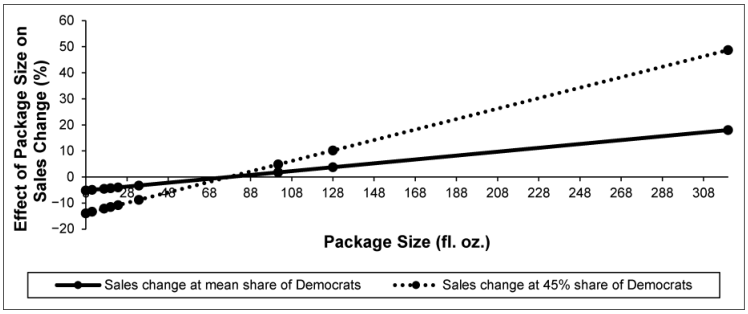

NOTE: figure/graphic rendered as an image from the PDF; its content is not machine-readable text. Caption (if any) follows as the next block.

and package sizes (β<sup>IA</sup>

3 <sup>=</sup><sup>−</sup><sup>.902,</sup> <sup>p</sup><sup>=</sup><sup>.002);</sup> <sup>that</sup> <sup>is,</sup> <sup>the</sup> <sup>shift</sup> toward larger bottles (and away from the bottle bill) is particularly strong among Republican-leaning markets, supporting that ideological aversion is linked to sales changes. Figure 7 visualizes this difference: The solid black line shows, for a market with an average share of Democrats in New York (59%), the effect of package size on the sales change for the nine observed package sizes (a slope of .074). The dotted line shows the same for a Republican-leaning market (45% share of Democrats, a slope of .201) and illustrates how the shift toward larger bottles is stronger by a factor of more than 2.7 (.201/.074).

We assess the robustness of our findings to this specification in six ways. First, we add the market’s average sales for a given package size before the bottle bill as an additional covariate instead of transforming the market-specific effect to a relative change. Second, we trim the market-specific effects at the 1% level to limit the influence of outliers. Third, we sequentially add three additional market-level controls: average household income, consumer environmental responsibility, and average household size, each entered as both a main effect and an interaction with package size. Fourth, we discretize package sizes into covered package sizes and noncovered package sizes.<sup>20</sup> Fifth, we account for the uncertainty in the sales change through weighted least squares by using the inverse of the dependent variable’s standard error as weight. Sixth, we replace the average housing unit size with a measure of urbanicity based on the 2010 U.S. Census. We provide additional details on the operationalizations and parameter estimates in Web Appendix K; there, we also provide the analog for price changes as the dependent variable. All robustness checks support the same pattern.

#### Consumer Switching and Price Sensitivity

Approach. We argue that consumers may respond to bottle bills by switching to larger package sizes, thereby changing the set of consumers who purchase smaller package sizes. To empirically test this driver, we use the NielsenIQ Consumer Panel Data (HMS) covering household purchases,<sup>21</sup> provided by the Kilts Center for Marketing, and focus on the period of one year before and after the introduction of the bottle bill. We aim to understand whether households that consolidate more of their purchases among larger package sizes are more price-sensitive, altering market-level elasticities.<sup>22</sup> To this end, we estimate a household-level choice model in which we estimate the choice of package size–multipack combination as a function of price and package size indicators.<sup>23</sup> Formally, we specify the utility

Figure 7. Effect of Bottle Bill by Package Size and Ideological Aversion. Notes: The slope at the mean share of Democrats (59%) is .074 (solid black line); at the 45% share of Democrats it is .201 (i.e., .074 −.902 × −.14) (dotted black line). Bubbles on lines indicate the package sizes in our sample.

20 In a similar spirit, we also estimate our model using only the estimates (ˆτs′ mi<sup>)</sup> for the sizes around the cutoff: 101.4 fl. oz. and 128 fl. oz. This approach should keep most other factors constant (e.g., inventory costs), except for the deposit. We again find that the share of Democrats is associated with lesser impacts of the bottle bill on sales.

21 In the context of this analyses, we assume consumer and household-level decisions are sufficiently similar. 22 In addition, the HMS data enable us to gain insights into purchase shifts at the household level, enabling us to corroborate the insights from our main analysis. To understand how households react to the bottle bill, we calculate several related household-level measures for each household for the periods before and after introduction of the bottle bill: water volume per bottle, number of bottles purchased, and total water volume purchased. We split the latter two measures into covered and noncovered bottles, enabling us to also calculate share-based measures (e.g., share of covered vs. noncovered bottles). We discuss the modeling approach in which we use treated households from New York and controls from states without bottle bills in Web Appendix L. We find that households buy fewer bottles (7%) after introduction of a bottle bill, which is driven by buying fewer bottles of sizes covered by the bottle bill. Similarly, we observe a volume sales drop (5%) for treated households that is driven by covered sizes, but no effect for control households. For treated households we observe that the share of covered sizes decreases in terms of bottles (−1.3%) as well as volume (−2.5%). Looking at the volume per bottle, we see that treated households buy larger sizes, with 7.1% additional volume per bottle. Jointly, these results (reported in Web Appendix L) corroborate the findings from our main analysis.

of each package size–multipack combination i at retailer r during a given trip t as follows:

Uirt = γ0 + γ1h × Pre BB priceirt + γ2h

× Post BB priceirt +

(γs,h × Ds)

+

(δs,h × BB × Ds) + δ0,h × BB + εirt, (4)

where γ0 is set to 0 and reflects the utility of the outside option, and γ1h × Pre_BB_priceirt captures the effects of the logtransformed price per fluid ounce (prior to the bottle bill) on the utility and is allowed to vary at the household level. That is, γ1h provides an estimate of the household-level sensitivity to price changes prior to the enactment of the bottle bill. The analog (γ2h × Post_BB_priceirt) captures the household-level effect of price per fluid ounce (without the bottle bill fee) after the bottle bill was put in place. Furthermore, we add size indicators (Ds for each of the nine package sizes, γs,h capturing a household-level utility preference for each size, where the mean γs=0,h is set to 0 for identification purposes). We include the term δs,h × BB × Ds for each package size, enabling us to capture to what extent preferences for a package size shift once the bottle bill (BB = 1) is implemented. These shifts in preferences are, again, household-specific and are captured by δs,h. Similarly, we allow for household-specific updates to the utility of the outside option once the bottle bill is implemented by using δ0,h × BB.

To gain insights into whether the price sensitivity of a household (measured by γ1h) is related to the changes in preferences for particular package sizes and the outside option (measured by δs,h and δ0,h), we allow the household-level parameters to be correlated. That is, we specify ten correlation parameters [r(γ1h, δs,h), r(γ1h, δ0,h)] that inform us about correlations between price sensitivities and updates to preferences for each of the nine package sizes and the outside option. The probability of a package-size multipack being chosen is given by

, for i ∈Cr,

where Cr contains the choice set on offer at a retailer. More specifically, it includes all package size–multipack combinations i offered by the retailer that the household visited on the trip when water was purchased.

Results. The results from Equation 4 enable us to test whether a household’s price sensitivity is related to utility shifts for particular package sizes and the outside option. The results, reported in Table W28 in Web Appendix M, show face valid negative

estimates for (log-transformed) price, with the mean of γ1h and γ2h being −.76 and −.31 (both with p < .001) in the periods before and after implementation of the bottle bill, suggesting a lower price sensitivity after enactment of the bill. The outside option increases substantially in terms of its utility after the enactment of the bottle bill (δ0,h = 4.690, p < .001). The correlation parameters that capture the relationship between the pre– bottle bill price sensitivities and shifts in preferences for the outside option and particular sizes are all positive, yet with no correlation statistically significant at the p < .05 level. Additionally, we calculate elasticities at the package size level using the pre–bottle bill median price per package. While elasticities for all sizes are smaller in magnitude, we do not find evidence of these shifts being more pronounced for covered package sizes. On the whole, the estimates do not reveal a structural pattern between a differential shift in preferences after the bottle bill was implemented. We report on the parameters, their correlation, and elasticities in Web Appendix M.

#### Additional Retailer Effort and Holding Costs

Approach. We argue that retail price increases for covered bottles are related to the additional effort and holding costs (i.e., ensuring correct labeling, opportunity costs of store space, and inventory holding costs) that a retailer experiences with the introduction of a bottle bill. To provide support for this mechanism, we assess retailer-specific price changes and relate these to different measures of operational effort. Specifically, we reestimate Equation 1 separately for each of the 17 retailers (and UPCs) and then aggregate to retailer–package size level (N = 99; not all retailers carry all package sizes). Next, we relate the retailerspecific estimates (ˆτ<sup>P</sup>

rj<sup>)</sup> <sup>to</sup> <sup>an</sup> <sup>indicator</sup> <sup>re</sup><sup>fl</sup><sup>ecting</sup> <sup>whether</sup> <sup>a</sup> package size is covered, a measure of additional effort, and their interaction effect. The interaction effect is of key interest and measures whether price changes for covered (vs. noncovered) package sizes are related to higher retailer effort and/or holding costs. We use two different measures: the variety of water UPCs and the importance of water in the store.

First, we use a retailer’s average number of unique water UPCs in a store. Presumably, the more UPCs a retailer offers and sells, the higher its effort of dealing with returns.<sup>24</sup> After all, retailers have to accept returns from all brands and sizes they sell; that is, more unique UPCs may mean more returns, too. One concern is that larger stores may also have more resources to deal with returns. If a store sells more unique water UPCs, it may also have more space and staff to deal with returns efficiently. To address this concern, we express, as a second measure, water sales as a percentage of soda sales. Water sales reflect the additional effort of the bottle bill,

23 This level of aggregation enables us to identify switching between package sizes rather than between UPCs. We consider all package size–multipack options with a choice share of over .1% for tractability reasons.

24 This assumes that consumers largely return bottles to the store where they purchased them. While we are not aware of detailed data linking purchase and return locations, a 2011 survey among more than 1,100 consumers at 96 retail stores in the state of New York found that more than two-thirds of consumers shop where they return empty bottles to receive their deposit refund (Stelling and Haight 2013).

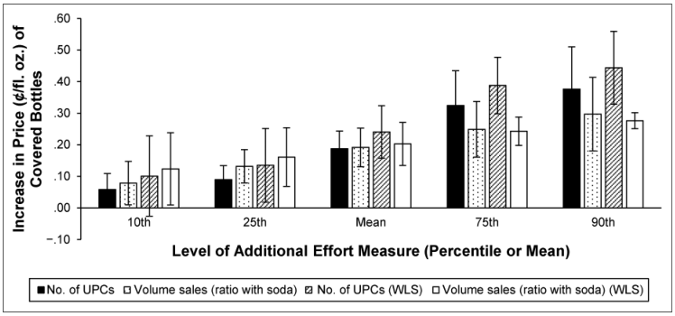

NOTE: figure/graphic rendered as an image from the PDF; its content is not machine-readable text. Caption (if any) follows as the next block.

while soda sales reflect a category already covered by a bottle bill. Importantly, a larger store is also likely to sell more soda. A larger ratio thus reflects how much additional effort and holding costs a retailer experiences, irrespective of the size.<sup>25</sup>

Thus, we estimate Equation 5:<sup>26</sup>

ˆτ<sup>P</sup>

3<sup>(covered</sup><sup>j</sup><sup>×</sup><sup>effort</sup><sup>r</sup><sup>)</sup><sup>+</sup><sup>ε</sup><sup>E</sup> rj<sup>.</sup> (5)

Results. We estimate Equation 5 both with ordinary least squares and weighted least squares to account for the uncertainty in our measure of ˆτ<sup>P</sup>

rj<sup>.</sup> <sup>We</sup> <sup>fi</sup><sup>nd</sup> <sup>a</sup> <sup>positive</sup> <sup>effect</sup> <sup>for</sup> <sup>the</sup> indicator of covered bottle sizes (β<sup>E</sup>

1 <sup>=</sup><sup>.188,</sup><sup>p</sup><sup>< .001), re</sup><sup>fl</sup><sup>ecting</sup> that prices tend to increase more (.188¢/fl. oz.) for covered package sizes than for noncovered package sizes, and no statistically significant effect for a store’s number of UPCs. More importantly, their interaction effect is positive and significant (β<sup>E</sup>

3 <sup>=</sup><sup>.012,</sup> <sup>p</sup><sup>< .001),</sup> <sup>indicating</sup> <sup>that</sup> <sup>the</sup> <sup>price</sup> <sup>change</sup> <sup>differen</sup>tial of covered and noncovered bottles increases as a retailer’s effort increases. We find comparable effects when using the ratio of water sales to soda sales (β<sup>E</sup>

3 <sup>=</sup><sup>.281,</sup> <sup>p</sup><sup>< .01)</sup> <sup>as</sup> <sup>a</sup> measure of additional retailer effort. Our findings are substantively similar when using weighted least squares, as opposed to ordinary least squares (see Web Appendix N). In Figure 8, we visualize this link: We present the average price change differential for covered bottles (compared with noncovered bottles) at different levels of retailer effort, represented by the 10th

percentile, 25th percentile, mean, 75th percentile, and 90th percentile of each measure. The overall insights are highly comparable across both measures: For retailers with less additional effort (10th percentile), prices for covered bottles increase by less than .1¢/fl. oz. more than for noncovered bottles, but for retailers with substantially more effort (90th), the increase can increase sixfold to .4¢/fl. oz.

#### Assessing the Replicability of the Bottle Bill Effects

As the robustness checks show, our findings remain consistent across several model specifications and analysis periods, but they all refer to New York’s bottle bill. To gain additional insights into the replicability of our findings, we investigate another bottle bill pertaining to water, introduced in the state of Connecticut around the same time as New York’s. The legislation also involves a 5¢ deposit per container and pertains to mostly the same package sizes, except that 101.4 fl. oz. packages are not covered in Connecticut. We provide more details about this sample in Tables W33–W34 of Web Appendix O. Using the same procedures as for New York, we identify control markets for Connecticut and reestimate Equations 1 and 2. Figure 9 depicts the results; we present detailed estimates in Tables W35–W36 in Web Appendix O.

Panel A (Panel B) of Figure 9 presents the price (total sales) changes by package size, for New York and Connecticut. The pattern of price increases for smaller package sizes and no changes for larger package sizes reappears for Connecticut. Notably, for 101.4 fl. oz., we see a price reduction in Connecticut, where it is a noncovered package. The total sales effect of the bottle bill introduction also holds in Connecticut. Next, we compare the cumulative sales change across all

Figure 8. Price Increase of Covered (vs. Noncovered) Bottles by Level of Additional Effort. Notes: Vertical bars show 95% confidence intervals. At an average price of 2.64¢/fl. oz. for a 16.9 fl. oz. bottle, the price adjustment ranges from 2% (10th percentile, black bars) to 14% (90th percentile), depending on retailers’ effort. We also present results (shaded and white bars) based on weighted least squares estimations (inverse of standard errors serving as weight) to account for the uncertainty in the dependent variable’s estimate. WLS = weighted least squares.

25 We note that we do not empirically distinguish between the additional efforts of ensuring correct labeling, opportunity costs of store space, and increased inventory holding costs but that these measures jointly reflect them. 26 We estimate a similar equation with volume sales changes as the dependent variable.

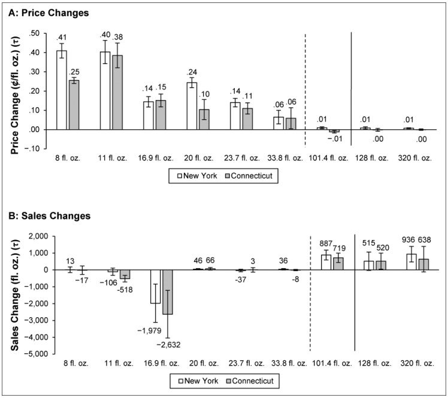

NOTE: figure/graphic rendered as an image from the PDF; its content is not machine-readable text. Caption (if any) follows as the next block.

#### Discussion

The first bottle bill was introduced in Denmark more than 100 years ago, but recently, these bills have grown in popularity across nations and states. Most research addresses the environmental implications of bottle bills rather than their marketing implications. We provide initial insights into bottle bills’

mechanisms and effects on sales and retail prices in the context of New York’s bottle bill for pure water. We document price increases of 4% and sales reductions of 6%. The price changes are implemented among covered package sizes smaller than 128 fl. oz., and sales of these packages suffer substantially, while larger package sizes gain. We propose and find suggestive evidence that consumers’ ideological aversion to governmental intervention is related to these sales changes, while retailers’ additional operational effort with bottle returns and holding costs are associated with higher prices.

#### Policy and Managerial Implications

Public health literature documents that bottle bills lead to substantially higher recycling rates; in the case of New York, they reach around 70% (Bottle Bill Resource Guide 2023b). By documenting the change in retail sales, which varies

Figure 9. Price and Sales Changes by Package Size: New York and Connecticut. Notes: Bars show ˆτ<sup>p</sup>

u <sup>(Panel A) and</sup> <sup>ˆ</sup><sup>τ</sup><sup>s</sup>

u <sup>(Panel B) along with 95% con</sup><sup>fi</sup><sup>dence intervals. The solid (dashed) vertical line represents the cutoff for covered package sizes</sup> in New York (Connecticut).

across package sizes, we specify the implications of the bottle bill in terms of the amount of plastic sold. Due to shifts toward larger package sizes, which typically use less plastic per volume of water, the overall amount of plastic sold may decrease, irrespective of changes in recycling behavior. However, consumers also may switch to packages not covered by the bottle bill, implying increased water sales in these sizes, which are not eligible for return, such that they may result in increased plastic waste and offset the benefits of increased recycling of covered packages. Our analysis shows that such concerns appear unwarranted, as any shifts across package sizes appear dwarfed by the reduction of plastic waste achieved through recycling. Put differently, the deposit fee on plastic bottles results in a limited change in plastic purchases at the aggregate level; however, plastic waste is affected through higher recycling rates. This is similar to Sanders’s (2024) finding that grocery store waste is inelastic with respect to the disposal costs of waste and that sizable waste reductions must be achieved through other means.<sup>27</sup>

These insights can expand policy perspectives, which usually target reduced environmental waste and increased recycling. Policies such as bottle bills are generally assumed to be sales-neutral for retailers, and unlike taxes, they are not explicitly designed to increase retail prices for consumers. We show that the policy leads to a reduction in sales by 6%, accompanied by 4% higher retail prices for consumers. We complement the retail data with information on the plastic weight per package size and can thus estimate the changes in “plastic sold,” that is, unit sales × plastic weight per unit. Thereby, we can quantify the plastic waste implications of consumers switching to larger bottles that are not covered by the bottle bill and hence not returned. While the observed price changes and shifts in purchased package sizes change the amount of plastic sold, this change is negligible compared with the increased recycling rates due to the bottle bill. Thus, in support of the policy goal of reducing plastic, the sales reduction exacerbates positive effects in plastic reduction through recycling by selling less to begin with. Last, we note that water consumption in itself can be of interest to policy makers and that decreases in water consumption may be unwelcome even if not paired with increasing consumption of unhealthy beverages.

#### Limitations and Further Research

Some limitations of our study provide fruitful avenues for further research. Our study is the first in marketing to study the sales and price implications of bottle bill introductions, and it produces remarkably consistent results across two introductions across two states. Yet, both states we study focus on still water and had bottle bills in place for other categories (e.g., soda). The numerous impending introductions of bottle bills across various categories provide rich settings to study heterogeneity along these dimensions.

For the broader topic of responsible retailing, the implications of retail price changes for society require further study. Does a reduction in bottled water sales (and increased recycling rate) only translate into less plastic used, or does it also have implications for water consumption? If consumers substitute bottled water with (safe) tap water, the societal benefits would be greater than if consumers just reduce their water consumption. We hope this study proves useful in managing the consequences of bottle bill introductions and stimulates further research at this increasingly important intersection of marketing and public policy.

Acknowledgments

The authors acknowledge the Kilts Center for Marketing at the University of Chicago Booth School of Business for providing access to the NielsenIQ RMS and HMS data. Researcher(s) own analyses calculated (or derived) based in part on data from Nielsen Consumer LLC and marketing databases provided through the NielsenIQ Datasets at the Kilts Center for Marketing Data Center at the University of Chicago Booth School of Business. The conclusions drawn from the NielsenIQ data are those of the researcher(s) and do not reflect the views of NielsenIQ. NielsenIQ is not responsible for, had no role in, and was not involved in analyzing and preparing the results 27 We thank an anonymous reviewer for highlighting this link.

reported herein. The authors thank Julien Bei, Michiel van Crombrugge, Raj Grewal, and Mike Palazzolo for helpful comments on an earlier version, and Mika and Leon Keller for superb research assistance.

Coeditor

Shrihari Sridhar

Associate Editor

Bryan Bollinger

Declaration of Conflicting Interests

The author(s) declared no potential conflicts of interest with respect to the research, authorship, and/or publication of this article.

Funding

The author(s) received no financial support for the research, authorship, and/or publication of this article.

ORCID iDs

Kristopher O. Keller https://orcid.org/0000-0002-6794-508X Jonne Y. Guyt https://orcid.org/0000-0001-8131-7664

References

Abadie, Alberto and Javier Gardeazabal (2003), “The Economic Costs

of Conflict: A Case Study of the Basque Country,” American Economic Review, 93 (1), 113–32. Alchian, Armen A. and William R. Allen (1972), University

Economics: Elements of Inquiry. Wadsworth. Alé-Chilet, Jorge and Sarah Moshary (2022), “Beyond Consumer

Switching: Supply Responses to Food Packaging and Advertising Regulations,” Marketing Science, 41 (2), 243–70. Allcott, Hunt, Levi Boxell, Jacob Conway, Matthew Gentzkow,

Michael Thaler, and David Yang (2020), “Polarization and Public Health: Partisan Differences in Social Distancing During the Coronavirus Pandemic,” Journal of Public Economics, 191, 104254. Allcott, Hunt, Benjamin B. Lockwood, and Dmitry Taubinsky (2019),

“Regressive Sin Taxes, with an Application to the Optimal Soda Tax,” Quarterly Journal of Economics, 134 (3), 1557–626. Alvarez, Santiago, Alberto Cavallo, Alexander MacKay, and Paolo Mengano (2025), “Markups and Cost Pass-Through Along the Supply Chain,” SSRN, https://doi.org/10.2139/ssrn.4935032. Arkhangelsky, Dmitry, Susan Athey, David A. Hirshberg, Guido

W. Imbens, and Stefan Wager (2021), “Synthetic Difference-in- Differences,” American Economic Review, 111 (12), 4088–118. Ashenmiller, Bevin (2011), “The Effect of Bottle Laws on Income: New

Empirical Results,” American Economic Review, 101 (3), 60–64. Berck, Peter and George Goldman (2003), “California Beverage

Container Recycling and Litter Reduction Study,” California Department of Conservation, https://www2.calrecycle.ca.gov/ Publications/Download/952?opt=dln. Bertrand, Marianne, Esther Duflo, and Sendhil Mullainathan (2004),

“How Much Should We Trust Differences-in-Differences Estimates?” Quarterly Journal of Economics, 119 (1), 249–75.

Bollinger, Bryan and Steven E. Sexton (2023), “Local Excise Taxes,

Sticky Prices, and Spillovers: Evidence from Berkeley’s Soda Tax,” Quantitative Marketing and Economics, 21, 281–331. Bottle Bill Resource Guide (2023a), “Litter Studies in Bottle Bill

States,” (accessed June 20, 2023), https://www.bottlebill.org/ index.php/benefits-of-bottle-bills/litter-studies-in-bottle-bill-states. Bottle Bill Resource Guide (2023b), “New York State Returnable

Beverage Container Act: Deposit and Redemption Statistics,” (accessed August 29, 2023), https://www.bottlebill.org/images/ PDF/Statewide_Bottle_Bill_Statistics_2009-2022.pdf. Butters, R. Andrew, Daniel W. Sacks, and Boyoung Seo (2022), “How

Do National Firms Respond to Local Cost Shocks?” American Economic Review, 112 (5), 1737–72. Butters, R. Andrew, Daniel W. Sacks, and Boyoung Seo (2025), “Why

Do Retail Prices Fall During Seasonal Demand Peaks?” RAND Journal of Economics, 56 (1), 35–54. Campbell, Benjamin, Hayk Khachatryan, Bridget Behe, Charles Hall,

and Jennifer Dennis (2016), “Crunch the Can or Throw the Bottle? Effect of ‘Bottle Deposit Laws’ and Municipal Recycling Programs,” Resources, Conservation and Recycling, 106, 98–109. Cawley, John, David Frisvold, David Jones, and Chelsea Lensing

(2021), “The Pass-Through of a Tax on Sugar-Sweetened Beverages in Boulder, Colorado,” American Journal of Agricultural Economics, 103 (3), 987–1005. Chetty, Raj, Adam Looney, and Kory Kroft (2009), “Salience and

Taxation: Theory and Evidence,” American Economic Review, 99 (4), 1145–77. Ching, Andrew T. and Daniel Goetz (2024), “Consumption Responses

to an Unpopular Policy: Evidence from a Short-Lived Soda Tax,” Marketing Science, 43 (6), 1204–25. Christen, Markus, Sachin Gupta, John C. Porter, Richard Staelin, and

Dick R. Wittink (1997), “Using Market-Level Data to Understand Promotion Effects in a Nonlinear Model,” Journal of Marketing Research, 34 (3), 322–34. Collins, Susan V., Jenny Gitlitz, Samantha Millette, Clarissa Morawski, and Jason Wilcox (2023), “The Impact of Deposit Return Systems on Beverage Sales,” Reloop (July), https://www.reloopplatform.org/wp-content/uploads/2023/08/Reloop- Impact-of-DRS-Report.pdf. Corkery, Michael (2019), “Beverage Companies Embrace Recycling,

Until It Costs Them,” New York Times (accessed February 2, 2024), https://www.nytimes.com/2019/07/04/business/plasticrecycling-bottle-bills.html. Cornelsen, Laura and Soledad Cuevas (2023), “Policy vs Business:

Well-Designed Health-Related Food Policy Should Not Let Industry Marketing Undermine Its Intended Effects: Comment on ‘Understanding Marketing Responses to a Tax on Sugary Drinks: A Qualitative Interview Study in the United Kingdom, 2019,’” International Journal of Health Policy and Management, 12 (1), 1–3. Costa, Dora L. and Matthew E. Kahn (2013), “Energy Conservation

‘Nudges’ and Environmentalist Ideology: Evidence from a Randomized Residential Electricity Field Experiment,” Journal of the European Economic Association, 11 (3), 680–702. Crosby, Lawrence A., James D. Gill, and James R. Taylor (1981),

“Consumer/Voter Behavior in the Passage of the Michigan Container Law,” Journal of Marketing, 45 (2), 19–32.

Crosby, Lawrence A. and James R. Taylor (1982), “Consumer

Satisfaction with Michigan’s Container Deposit Law—an Ecological Perspective,” Journal of Marketing, 46 (1), 47–60. Cullen, Julie Berry, Nicholas Turner, and Ebonya Washington (2021),

“Political Alignment, Attitudes Toward Government, and Tax Evasion,” American Economic Journal: Economic Policy, 13 (3), 135–66. DellaVigna, Stefano and Matthew Gentzkow (2019), “Uniform Pricing

in U.S. Retail Chains,” Quarterly Journal of Economics, 134 (4), 2011–84. Fullerton, Don and Ann Wolverton (2000), “Two Generalizations of a

Deposit–RefundSystem,”AmericanEconomicReview,90(2),238–42. Gathright, Jenny and Meagan Flynn (2025), “D.C. Council Bill Would

Allow Bottles and Cans to Be Recycled for Cash,” Washington Post (January 17), https://www.washingtonpost.com/dc-md-va/2025/01/ 17/dc-bottle-bill-recycling-cans/. Gibbons, Lauren (2021), “Michigan’s Bottle Deposit Law: Will the

1970s Bill Ever Change?” Michigan Live (November 9), https:// www.mlive.com/public-interest/2021/11/michigans-bottle-depositlaw-will-the-1970s-bill-ever-change.html. Guyt, Jonne Y., Arjen van Lin, and Kristopher O. Keller (2025),

“Banning Unsolicited Store Flyers: Does Helping the Environment Hurt Retailing?” Marketing Science (published online May 5, 2025), https://doi.org/10.1287/mksc.2023.0020. Hwang, Minha, Bart J. Bronnenberg, and Raphael Thomadsen (2010),

“An Empirical Analysis of Assortment Similarities Across U.S. Supermarkets,” Marketing Science, 29 (5), 858–79. International Bottled Water Association (2009), “Connecticut’s Bottled

Water Deposit Fee Will Hurt Consumers, Jeopardize Businesses, and Impact Negatively on Statewide Curbside Recycling Efforts,” press release (March 3), https://bottledwater.org/nr/connecticut-sbottled-water-deposit-fee-will-hurt-consumers-jeapordize-businessesand-impact-negatively-on-statewide-curbside-recycling-efforts/. IRI (2018), “The Impact of the Container Deposit Scheme (CDS) on

NSW Grocery & Liquor.” Jones, Jeffrey M. (2023), “Record Party Gap on Environment-

Economic Growth Tradeoff,” Gallup (April 13), https://news. gallup.com/poll/474218/record-party-gap-environment-economicgrowth-tradeoff.aspx. Keller, Kristopher O., Jonne Y. Guyt, and Rajdeep Grewal (2024),

“Soda Taxes and Marketing Conduct,” Journal of Marketing Research, 61 (3), 393–410. Kim, Sungjin, Clarence Lee, and Sachin Gupta (2020), “Bayesian

Synthetic Control Methods,” Journal of Marketing Research, 57 (5), 831–52. Li, Kathleen T. and Christophe Van den Bulte (2023), “Augmented

Difference-in-Differences,” Marketing Science, 42 (4), 746–67. Livengood, Chad (2022), “Retailers, Environmentalists Fed Up with

‘Broken’ Bottle Return Law,” Detroit News (December 18), https://www.detroitnews.com/story/news/local/michigan/2022/12/ 19/livengood-retailers-environmentalists-fed-up-with-bottle-returnlaw/69725561007/. Massachusetts Department of Environmental Protection (2011), “Comparison of Beverage Pricing, Consumer Choice and Redemption System Performance in Massachusetts and Neighboring States.”

McShane, Blakeley B., Chaoqun Chen, Eric T. Anderson, and Duncan

I. Simester (2016), “Decision Stages and Asymmetries in RegularRetailPricePass-Through,”MarketingScience,35(4),619–39. Moses, Lucia (2005), “Industry, States Battle Over Bottle Bills,”

Supermarket News (November 28), https://www.supermarketnews. com/grocery-operations/industry-states-battle-over-bottle-bills. Nevo, Aviv and Konstantinos Hatzitaskos (2005), “Why Does the

Average Price of Tuna Fall During Lent?” National Bureau of Economic Research Working Paper 11572, https://doi.org/10. 3386/w11572. New York State (2014), “Litter and Solid Waste Control,” Article 27,

Collection, Treatment and Disposal of Refuse and Other Solid Waste, Title 10, Litter and Solid Waste Control (27-1001), https:// www.nysenate.gov/legislation/laws/ENV/27-1001. OECD (2022), “Plastic Pollution Is Growing Relentlessly as Waste

Management and Recycling Fall Short,” press release (February 22), https://www.oecd.org/environment/plastic-pollution-is-growingrelentlessly-as-waste-management-and-recycling-fall-short.htm. Pew Research Center (2009), “Section 9: The Environment and the

Economy,” (May 21), https://www.pewresearch.org/politics/2009/ 05/21/section-9-the-environment-and-the-economy/. Pilling, Bruce K., Lawrence A. Crosby, and Pam Scholder Ellen

(1991), “Using Benefit Segmentation to Influence Environmental Legislation: A Bottle Bill Application,” Journal of Public Policy & Marketing, 10 (2), 28–46. Porter, Richard C. (1983), “Michigan’s Experience with Mandatory

Deposits on Beverage Containers,” Land Economics, 59 (2), 177–94. Porter, Richard C. (2002), The Economics of Waste. Routledge. Quinn, Megan (2022), “California Bottle Bill Adds Wine and Spirits,

Plus Last-Minute Funding for Glass Markets and Recycling,” Waste Dive (September 2), https://www.wastedive.com/news/ california-bottle-bill-wine-spirits-glass-expansion/631125/. Quinn, Megan (2025), “D.C.’s Proposed Bottle Bill Aims to Tackle

Pollution,” Packaging Dive (January 29), https://www.packagingdive. com/news/washington-dc-bottle-bill-environmental-justice-river-pollution/ 738435/. Saleem, Junaid, Furqan Tahir, Moghal Zubair Khalid Baig, Tareq Al-Ansari, and Gordon McKay (2023), “Assessing the Environmental Footprint of Recycled Plastic Pellets: A Life-Cycle Assessment Perspective,” Environmental Technology & Innovation, 32, 103289. Sanders, Robert Evan (2024), “Dynamic Pricing and Organic Waste

Bans: A Study of Grocery Retailers’ Incentives to Reduce Food Waste,” Marketing Science, 43 (2), 289–316. Seiler, Stephan, Anna Tuchman, and Song Yao (2021), “The Impact of

Soda Taxes: Pass-Through, Tax Avoidance, and Nutritional Effects,” Journal of Marketing Research, 58 (1), 22–49. Sjolander, Richard and Peter Kakela (1988), “Michigan’s Mandatory

Beverage-Container-Deposit Law: Economic Effects of a Public Policy on Industry Sales,” Journal of Public Policy & Marketing, 7 (1), 166–84. Stelling, Joseph and Laura Haight (2013), “Shop Where You Drop: A

Survey of Consumer Bottle Return Habits,” New York Public Interest Research Group, https://www.nypirg.org/pubs/enviro/ 2013.02.04ShopWhereYouDrop.pdf.

Sussman, Abigail B. and Christopher Y. Olivola (2011), “Axe the Tax:

Taxes Are Disliked More Than Equivalent Costs,” Journal of Marketing Research, 48 (Special Issue), S91–S101. Viscusi, W. Kip, Joel Huber, Jason Bell, and Caroline Cecot (2013),

“Discontinuous Behavioral Responses to Recycling Laws and Plastic Water Bottle Deposits,” American Law and Economics Review, 15 (1), 110–55.

Whiting, Brandon (2024), “E-Can-Omics: The Impact of Raised

Deposits,” Connecticut Inside Investigator (September 29), https:// insideinvestigator.org/e-can-omics-the-impact-of-raiseddeposits/. Wiener, Joshua L. (1993), “What Makes People Sacrifice Their

Freedom for the Good of Their Community?” Journal of Public Policy & Marketing, 12 (2), 244–51.